# Adaptive therapy

Model simulation of adaptive therapy

Author

Nicholas Harbour

Modified

January 16, 2025, 16:00:54

[Mathematical Model-Driven Deep Learning Enables Personalized Adaptive Therapy](https://aacrjournals.org/cancerres/article/84/11/1929/745515)

You will need the following packages to run the code:

```python
import numpy as np
import matplotlib.pyplot as plt
```

# 1 Lotka-voltera virtual patient model

To simulate a virtaul-patient they use the Lotka-voltera model introduced in Strobl et al.

$$\begin{align}
\frac{dS}{dt} &= r_S S (1 - \frac{S + R}{K})(1 - d_D D) - d_S S\\
\frac{dR}{dt} &= r_R R (1 - \frac{S + R}{K}) - d_R R
\end{align}$$

Where $S(t)$ is the number of sensitive cells, $R(t)$ is the number of resistant cells. $K$ is the carrying capacity of the system, $r_S$ and $r_R$ are the growth rates of the sensitive and resistant cells respectively. $d_S$ and $d_R$ are the death rates of the sensitive and resistant cells respectively. Treatment is assumed to kill sensitive cells at a rate that is proportional to the growth rate and Drug concertation $D(t)$, with proportionality constant $d_D$.

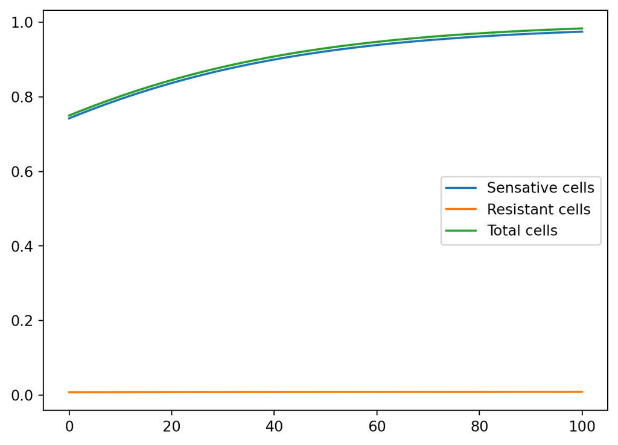

```python
t = np.linspace(0,100,1001)
dt = t[1] - t[0]
S = np.zeros_like(t)
R = np.zeros_like(t)

def lotka_voltera(t, y, r_S, r_R, K, d_S, d_R, d_D, D):
    S, R = y
    dSdt = r_S * S * (1 - (S + R) / K) * (1 - d_D * D) - d_S * S
    dRdt = r_R * R * (1 - (S + R) / K) - d_R * R
    return [dSdt, dRdt]

# Virtual patinet parameters from the supliment
r_S = 0.03  # /day # sensative cells proliferation rate
r_R = 0.5 * r_S # 0.5*r_S - 1*r_S # Resistiant cells proliferation rate
d_S = 0 * r_S # 0*r_S - 0.5*r_S # sensative cells death rate
d_R = 0 * r_S # 0*r_S - 0.5*r_S # Resistiant cells death rate
d_D = 1.5 # Drug induced cell killing
N_0 = 0.75 # Inital tumor size 0.1-0.75
R_0 = 0.01 * N_0 # Inital resistant cell population: 0.001*N_0 - 0.1*N_0
K = 1 # Carrying capacity
D = 0

# Set the IC
R[0] = R_0
S[0] = N_0 - R_0

for i in range(len(t)-1):

    RHS = np.array(lotka_voltera(t[i], [S[i], R[i]], r_S, r_R, K, d_S, d_R, d_D,D))
    S[i+1] = S[i] + RHS[0] * dt
    R[i+1] = R[i] + RHS[1] * dt



N = S + R

plt.plot(t, S, label='Sensative cells')
plt.plot(t, R, label='Resistant cells')
plt.plot(t, N, label='Total cells')

plt.legend()
```

# 2 Simulated treatment

1. CT - continous therapy (standard of care).
   $$D(t) = 1 \; \forall t$$
2. AT - adaptive therapy, treatment is is given until 50% decrease from the initial size $N_0$, it is then withdrawn until the tumor returns to the original size $N_0$
   $$D(t) = \begin{cases}
   1 & \text{until } N(t) < 0.5 N_0\\
   0 & \text{until } N(t) \geq 0.5 N_0
   \end{cases}$$

Define time to progression as the time it takes for the tumor to reach 1.2 times the initial size $N_0$.

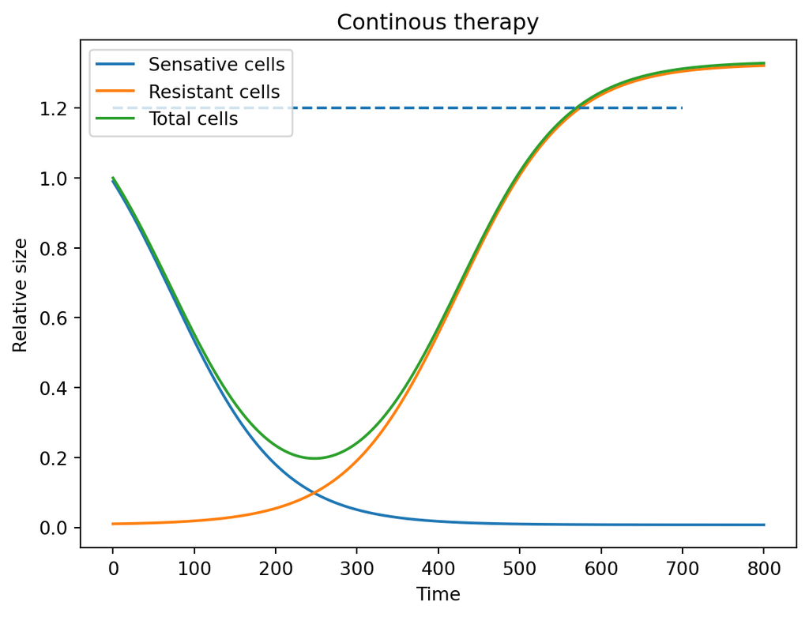

```python
def cont_therapy(t, N_0,R_0, r_S, r_R, K, d_S, d_R, d_D):

    S = np.zeros_like(t)
    R = np.zeros_like(t)
    N = np.zeros_like(t)
    D = 1
    dt = t[1] - t[0]
    # Set the IC
    R[0] = R_0
    S[0] = N_0 - R_0
    N[0] = N_0


    for i in range(len(t)-1):





        RHS = np.array(lotka_voltera(t[i], [S[i], R[i]], r_S, r_R, K, d_S, d_R, d_D,D))
        S[i+1] = S[i] + RHS[0] * dt
        R[i+1] = R[i] + RHS[1] * dt
        N[i+1] = S[i+1] + R[i+1]





    return [S, R, N]


t = np.linspace(0,800,1001)
S, R, N = cont_therapy(t, N_0,R_0, r_S, r_R, K, d_S, d_R, d_D)

# Calcualte relative size compared to IC
N_rel = N / N_0
S_rel = S / (N_0 )
R_rel = R / N_0


plt.plot(t, S_rel, label='Sensative cells')
plt.plot(t, R_rel, label='Resistant cells')
plt.plot(t, N_rel, label='Total cells')
plt.title('Continous therapy')
plt.ylabel('Relative size')
plt.xlabel('Time')

plt.hlines(1.2,0,700,linestyles='dashed')

plt.legend()
```

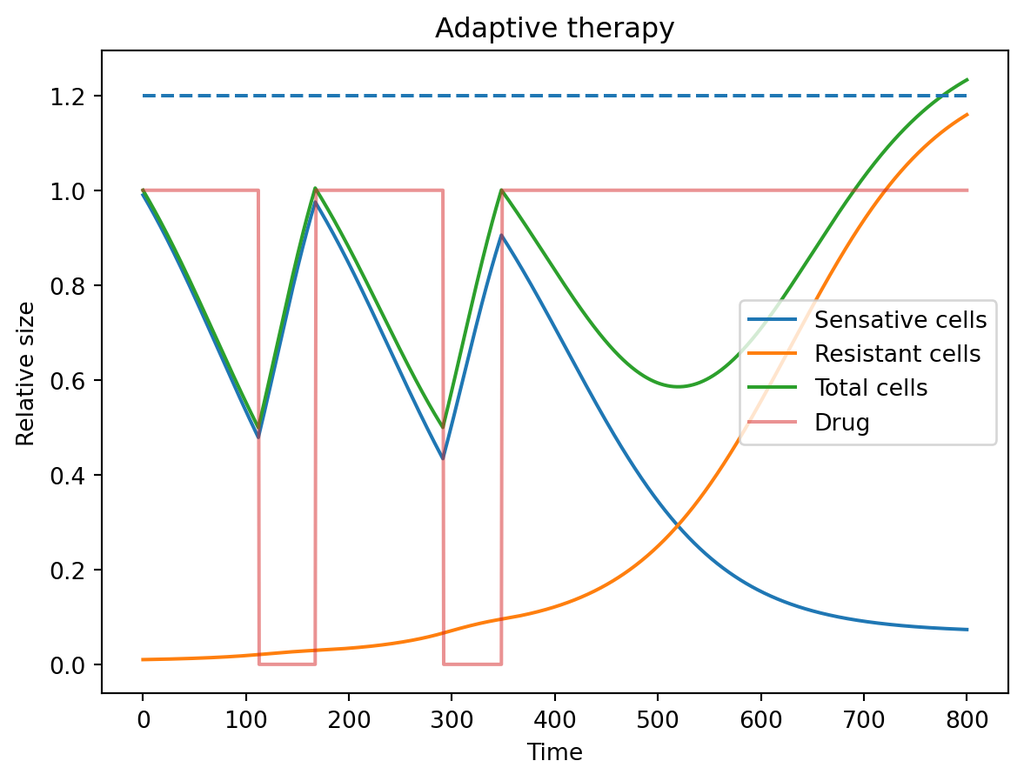

```python
def adaptive_therapy(t, N_0,R_0, r_S, r_R, K, d_S, d_R, d_D):

    S = np.zeros_like(t)
    R = np.zeros_like(t)
    N = np.zeros_like(t)
    D_save = [1]
    dt = t[1] - t[0]
    # Set the IC
    R[0] = R_0
    S[0] = N_0 - R_0
    N[0] = N_0


    for i in range(len(t)-1):


        if N[i] >= N_0:
            D = 1

        elif N[i] <= 0.5 * N_0:
            D = 0




        RHS = np.array(lotka_voltera(t[i], [S[i], R[i]], r_S, r_R, K, d_S, d_R, d_D,D))
        S[i+1] = S[i] + RHS[0] * dt
        R[i+1] = R[i] + RHS[1] * dt
        N[i+1] = S[i+1] + R[i+1]
        D_save.append(D)





    return [S, R, N, D_save]


t = np.linspace(0,800,1001)
S, R, N, D_save = adaptive_therapy(t, N_0,R_0, r_S, r_R, K, d_S, d_R, d_D)

# Calcualte relative size compared to IC
N_rel = N / N_0
S_rel = S / (N_0 )
R_rel = R / N_0


plt.plot(t, S_rel, label='Sensative cells')
plt.plot(t, R_rel, label='Resistant cells')
plt.plot(t, N_rel, label='Total cells')
plt.plot(t, D_save, label='Drug', alpha=0.5)
plt.title('Adaptive therapy')
plt.ylabel('Relative size')
plt.xlabel('Time')

plt.hlines(1.2,0,800,linestyles='dashed')

plt.legend()
```

# 3 Nieve treatment agent

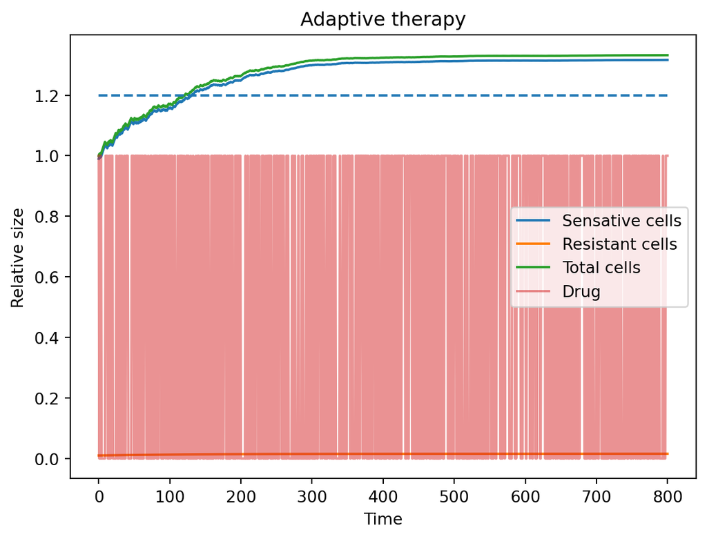

```python
def random_agent(N):
    D = np.random.choice([0,1])
    return D


def random_therapy(t, N_0,R_0, r_S, r_R, K, d_S, d_R, d_D):

    S = np.zeros_like(t)
    R = np.zeros_like(t)
    N = np.zeros_like(t)
    D_save = [1]
    dt = t[1] - t[0]
    # Set the IC
    R[0] = R_0
    S[0] = N_0 - R_0
    N[0] = N_0


    for i in range(len(t)-1):


        D = random_agent(N[i])



        RHS = np.array(lotka_voltera(t[i], [S[i], R[i]], r_S, r_R, K, d_S, d_R, d_D,D))
        S[i+1] = S[i] + RHS[0] * dt
        R[i+1] = R[i] + RHS[1] * dt
        N[i+1] = S[i+1] + R[i+1]
        D_save.append(D)





    return [S, R, N, D_save]


t = np.linspace(0,800,1001)
S, R, N, D_save = random_therapy(t, N_0,R_0, r_S, r_R, K, d_S, d_R, d_D)

# Calcualte relative size compared to IC
N_rel = N / N_0
S_rel = S / (N_0 )
R_rel = R / N_0


plt.plot(t, S_rel, label='Sensative cells')
plt.plot(t, R_rel, label='Resistant cells')
plt.plot(t, N_rel, label='Total cells')
plt.plot(t, D_save, label='Drug', alpha=0.5)
plt.title('Adaptive therapy')
plt.ylabel('Relative size')
plt.xlabel('Time')

plt.hlines(1.2,0,800,linestyles='dashed')

plt.legend()
```